# Titanic: Machine Learning from Disaster

Abhijeet Sharma

Sunday, July 05, 2015

[output not shown]

# Step 1: Fetching data from the training and testing files

```r
train <- read.csv(file="../data/train.csv", header=TRUE, sep=",", quote="\"",
                  stringsAsFactors=FALSE, na.strings=c("NA",""))
test <- read.csv(file="../data/test.csv", header=TRUE, sep=",", quote="\"",
                  stringsAsFactors=FALSE, na.strings=c("NA",""))
```

We now check the structure of the training dataset

```r
str(train)
```

```
## 'data.frame':    891 obs. of  12 variables:
##  $ PassengerId: int  1 2 3 4 5 6 7 8 9 10 ...
##  $ Survived   : int  0 1 1 1 0 0 0 0 1 1 ...
##  $ Pclass     : int  3 1 3 1 3 3 1 3 3 2 ...
##  $ Name       : chr  "Braund, Mr. Owen Harris" "Cumings, Mrs. John Bradley (Florence Briggs Thayer)" "Heikkinen, Miss. Laina" "Futrelle, Mrs. Jacques Heath (Lily May Peel)" ...
##  $ Sex        : chr  "male" "female" "female" "female" ...
##  $ Age        : num  22 38 26 35 35 NA 54 2 27 14 ...
##  $ SibSp      : int  1 1 0 1 0 0 0 3 0 1 ...
##  $ Parch      : int  0 0 0 0 0 0 0 1 2 0 ...
##  $ Ticket     : chr  "A/5 21171" "PC 17599" "STON/O2. 3101282" "113803" ...
##  $ Fare       : num  7.25 71.28 7.92 53.1 8.05 ...
##  $ Cabin      : chr  NA "C85" NA "C123" ...
##  $ Embarked   : chr  "S" "C" "S" "S" ...
```

We observe that there are many fields we can convert to factors.

# Step 2: Pre-processing.

## Step 2.1: Cleaning the training dataset.

```r
# Passenger Id has no meaning for this analysis, so we remove it from the
# training dataset.
train <-  subset(train, select= -c(PassengerId))
# There are some columns which are more meaningful if we convert them to factors.
train$Survived <- factor(train$Survived, levels = c("0", "1"),
                         labels = c("Not_Survived", "Survived"))
train$Pclass <- factor(train$Pclass)
train$Sex <- factor(train$Sex)
train$Embarked <- factor(train$Embarked)
```

Now that all the proper columns are converted to factors, we move on to handling the “NA” fields.

## Step 2.2: Handling NA’s

```r
# deleting all rows having atleast one NA
train_wo_na <- train[complete.cases(train),]
dim(train_wo_na)
```

```
## [1] 183  11
```

```r
dim(train)
```

```
## [1] 891  11
```

It’s evident that we cannot simply delete the NA rows as we are left with only 20% data.

We approach this in a column-to-column basis.

```r
summary(train)
```

```
##          Survived   Pclass      Name               Sex
##  Not_Survived:549   1:216   Length:891         female:314
##  Survived    :342   2:184   Class :character   male  :577
##                     3:491   Mode  :character
##
##
##
##
##       Age            SibSp           Parch           Ticket
##  Min.   : 0.42   Min.   :0.000   Min.   :0.0000   Length:891
##  1st Qu.:20.12   1st Qu.:0.000   1st Qu.:0.0000   Class :character
##  Median :28.00   Median :0.000   Median :0.0000   Mode  :character
##  Mean   :29.70   Mean   :0.523   Mean   :0.3816
##  3rd Qu.:38.00   3rd Qu.:1.000   3rd Qu.:0.0000
##  Max.   :80.00   Max.   :8.000   Max.   :6.0000
##  NA's   :177
##       Fare           Cabin           Embarked
##  Min.   :  0.00   Length:891         C   :168
##  1st Qu.:  7.91   Class :character   Q   : 77
##  Median : 14.45   Mode  :character   S   :644
##  Mean   : 32.20                      NA's:  2
##  3rd Qu.: 31.00
##  Max.   :512.33
##
```

```r
sum(is.na(train$Cabin))
```

```
## [1] 687
```

```r
sum(complete.cases(subset(train, select=-Cabin)))
```

```
## [1] 712
```

Even though it’s not evident in the summary, We observe from the data that most of the NAs are because of the *Cabin* column.Hence, if we ignore this column, we still have 80% data left. We’ll create a **Naive** version of our train set and observe the performance.

```r
# We are ignoring this columns for now.
# TODO: analyze any use of the Cabin column.
train <-  subset(train, select= -Cabin)

# We first try the Naive version where we ignore all NAs in the train set.
# TODO: Predict the missing Age and Embarked columns.
train_naive <- train[complete.cases(train),]
# In the Naive version, we also ignore the "Name"  and "Ticket" columns.
train_naive <- subset(train_naive, select= -c(Name, Ticket))
head(train_naive)
```

```
##       Survived Pclass    Sex Age SibSp Parch    Fare Embarked
## 1 Not_Survived      3   male  22     1     0  7.2500        S
## 2     Survived      1 female  38     1     0 71.2833        C
## 3     Survived      3 female  26     0     0  7.9250        S
## 4     Survived      1 female  35     1     0 53.1000        S
## 5 Not_Survived      3   male  35     0     0  8.0500        S
## 7 Not_Survived      1   male  54     0     0 51.8625        S
```

# Step 3: Analyze Plots

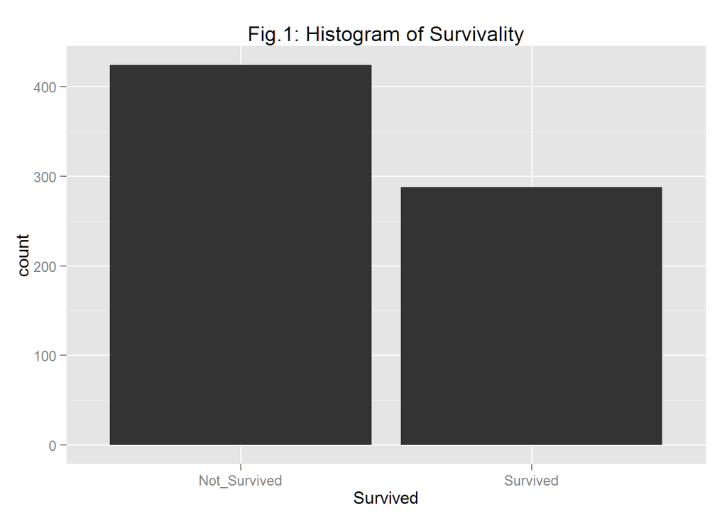

We observe from this plot that almost 60% didn’t survive the disaster.

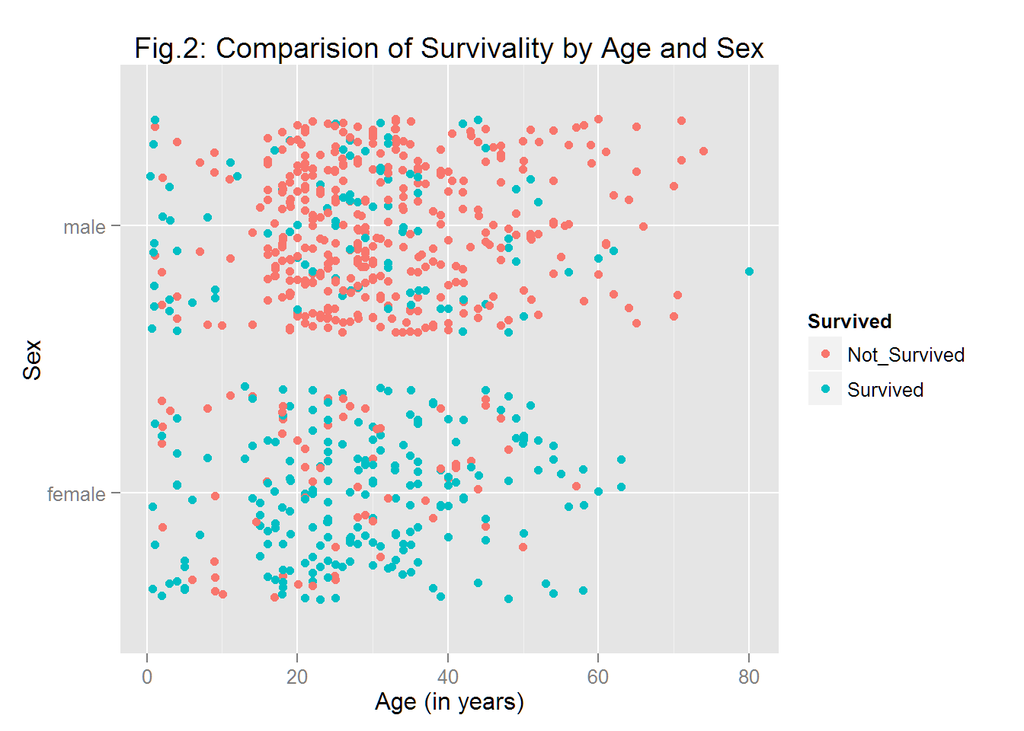

We observe from this plot that higher percentage of females across all ages survived whereas for males, there was higher survival rate for children but lower survival rate for adults.This confirms the “Women and Children First” policy used for the lifeboats.

[figure not shown]

We observe from the above plot that as the no. of siblings increase, survivality has decreased. We plot a histogram to confirm the above observation.

[figure not shown]

The distribution of the number of siblings is not uniform to prove our theory. we plot another histogram and this time we show the relative frequencies.

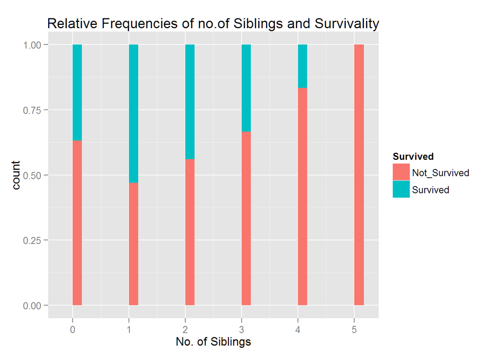